# Classification 4G Mobile site

PCA and classification

L.RANT

13 décembre, 2019

# 1.Introduction

Les réseaux LTE sont des réseaux cellulaires constitués de milliers de cellules radio qui utilisent les mémes fréquences hertziennes, y compris dans les cellules radio mitoyennes, grace aux codages radio OFDMA (de la base vers le terminal) et SC-FDMA (du terminal vers la base). Ceci permet d’affecter à chaque cellule une largeur spectrale plus importante qu’en 3G, variant de 3 à 20 MHz et donc d’avoir une bande passante plus importante et plus de débit dans chaque cellule.

Orange France a ouvert pour ses clients “entreprises” un premier réseau expérimental 4G/LTE au mois de juin 2012 à Marseille. Orange annonéait pouvoir couvrir 40 % de la population française fin 2013. En octobre 2018, Orange couvre 85 % du territoire soit 98 % de la population.

Les bandes de fréquences hertziennes prévues par les normes 3GPP pour le LTE et le LTE Advanced sont trés nombreuses (plus de 30) et s’étalent de 450 MHz à 3,8 GHz. Celles situées dans la zone des 450 à 900 MHz sont utilisables sur tous les territoires et sont particuliérement adaptées aux zones rurales car elles ont une plus grande portée que les ondes radio de fréquences plus élevées. Le rayon de couverture de chaque cellule est variable, allant de quelques centaines de métres (débits optimaux en zones urbaines denses) jusqu’é 30 km (zones rurales).

Ces variables ont été extraits de la base de données réseaux mobiles d’Orange dans le département du 78 en IDF pour la partie LTE. Cet extrait regroupe des informations de l’activité de chaque cellule. Notamment, nous retrouvons une agrégation mensuelle de ces informations. Le présent rapport s’intéresse é l’activité des cellules sur la période de janvier 2019 dans le département du 78 via le jeu de données extrait de la base de données.

Est-ce que toutes les cellules ont la méme activitéé Existent-ils des cellules émoins bonneséé qu’est-ce qui les caractérisenté y a-t-il un moyen de différencier les cellules en fonction de l’activité réseaué Peut-on mettre en évidence les défaillances et proposer un axe d’améliorationé

Dans un premier temps, nous ferons une analyse du jeu de données pour bien les comprendre et trouver une limite à leurs utilisations. Ensuite nous procéderons à une Analyse en Composantes Principales (ACP) dans le but de mettre en évidence une typologie des cellules. Enfin, nous essayerons de regrouper les cellules selon des attributs qui leur sont propres au travers d’une classification.

Cette étude a été réalisé avec le logiciel R en s’appuyant sur l’IDE RStudio.

# 2.Analyse préalable

Il est nécessaire de bien comprendre ce que nous analysons pour émettre un avis critique. Ainsi, nous avons défini plus haut de maniére macro le fonctionnement des réseaux. Qu’est-ce qu’une celluleé

**Le role d’une cellule LTE**

Une station relais est munie de cellules émettrices et réceptrices qui, à l’aide d’ondes électromagnétiques, assurent la liaison avec tout téléphone mobile situé dans sa cellule. Chaque station est reliée é un central téléphonique, qui traite les informations (identification de l’appelant, et localisation de l’appelé). Lorsqu’un utilisateur de téléphone portable quitte la cellule, une liaison s’établit automatiquement avec la station relais de la cellule voisine.

Pour résumer, chaque antenne relais peut étre constituée d’une ou plusieurs cellules de bande de fréquence différentes LTE800, LTE1800, LTE2100 ou LTE2600 .

Chaque cellule a une bande de fréquence spécifique, voici les différentes bandes utilisées dans le jeu de données:

**Bande des 800 MHz**

Cette bande de fréquence est dédiée au LTE et au LTE Advanced et est disponible depuis janvier 2012.

**Bande des 1800 MHz**

Cette bande de fréquence a une utilisation mixte 2G (GSM) et LTE.

**Bande des 2100 MHz**

Les fréquences dans la bande des 2 100 MHz sont historiquement utilisées pour l’UMTS. Néanmoins depuis le 16 juin 2017, l’Arcep a autorisé les opérateurs é utiliser ces fréquences, ou une partie de ces fréquences, pour la 4G.

**Bande des 2600 MHz**

Cette bande de fréquence est dédiée au LTE et au LTE Advanced.

Les avantages et inconvénients des diverses bandes de fréquences: La plus grande disponibilité des fréquences hautes (ex : 2 600 MHz) a permis d’attribuer à chaque opérateur mobile des bandes de fréquences plus larges (15 ou 20 MHz duplex en France) ; ces bandes supportent plus de sous-porteuses et permettent donc des débits plus importants comparé é la bande de fréquence des 800 MHz qui en France est découpée en sous bandes de 10 MHz duplex par opérateur. Cependant, les fréquences basses ont une plus grande portée (une meilleure propagation dans l’atmosphére) et permettent donc de couvrir des zones de plus grande surface car l’atténuation des ondes radio entre 2 antennes décroét avec la longueur d’onde ; une fréquence plus basse (donc une longueur d’onde supérieure) permet aux opérateurs d’atteindre plus d’abonnés avec un méme nombre d’antennes.

**Le jeu de données**

Nous allons étudier un jeu de données qui contient 906 cellules (individus) sur le mois de janvier 2019 avec 21 variables dont 13 variables quantitatives représentés par des Key performance indicator (KPI) et 8 variables qualitatives illustratives qui représentent la configuration de la cellule.

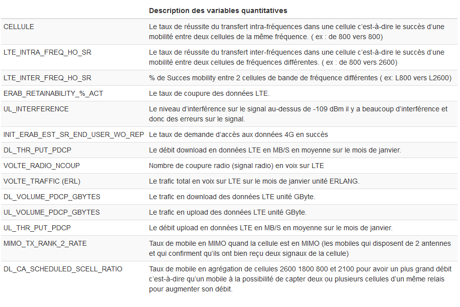

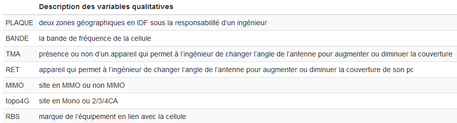

# 3.Analyse en Composantes Principales

## 1. Observation des cellules extrémes

L’analyse des graphes détecte des cellules singuliers qui influencent trés fortement les résultats observés. Le caractére extréme de ces cellules nous oblige de les retirer dans un premier temps pour procéder é la suite de l’analyse. Nous avons nettoyé les cellules 4G qui étaient hors services et qui sont représentés par des KPI égale é 0. Nous allons lancer une ACP pour caractérisation des groupes des cellules par les variables, pour comprendre les liaisons entre variables des cellules spécifiques.

## 2. Distribution de l’inertie

L’inertie des axes factoriels indique d’une part si les variables sont structurées et suggére d’autre part le nombre judicieux de composantes principales à étudier. Les 2 premiers axes de l’ACP expriment 40.19% de l’inertie totale du jeu de données ; cela signifie que 40.19% de la variabilité totale du nuage des cellules (ou des variables) est représentée dans ce plan. Nous allons considérer jusqu’é 5 dimensions dans l’analyse.

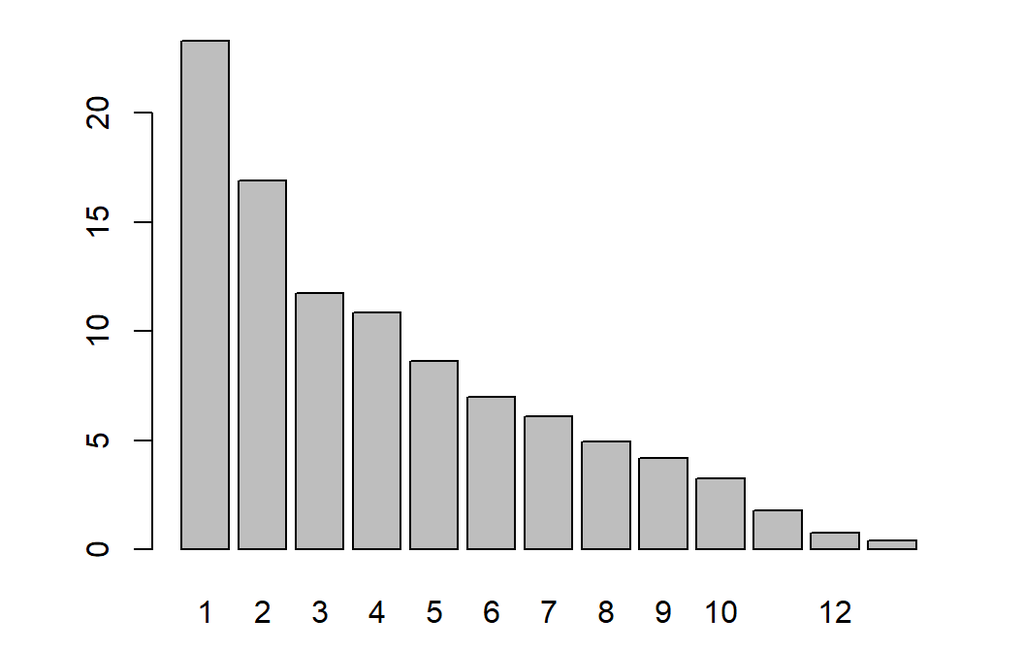

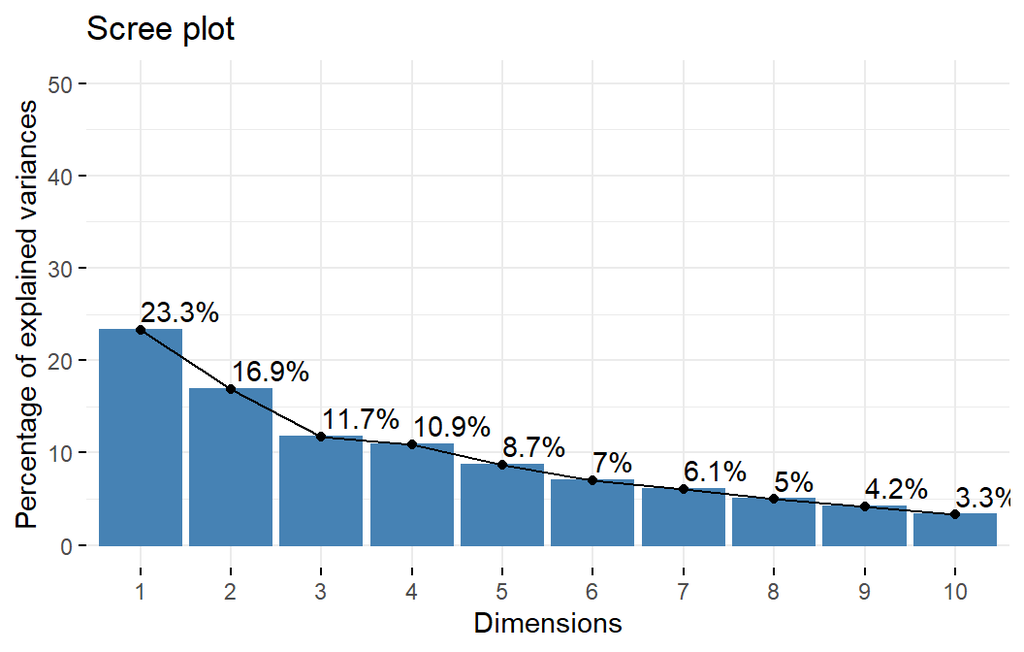

**Figure 2 - Décomposition de l’inertie totale**

Une estimation du nombre pertinent d’axes à interpréter suggére de restreindre l’analyse à la description des 5 premiers axes. Ces composantes révélent un taux d’inertie supérieur é celle du quantile 0.95 de distributions aléatoires (71.47% contre 43.8%).

## 3. Description du plan 1:2

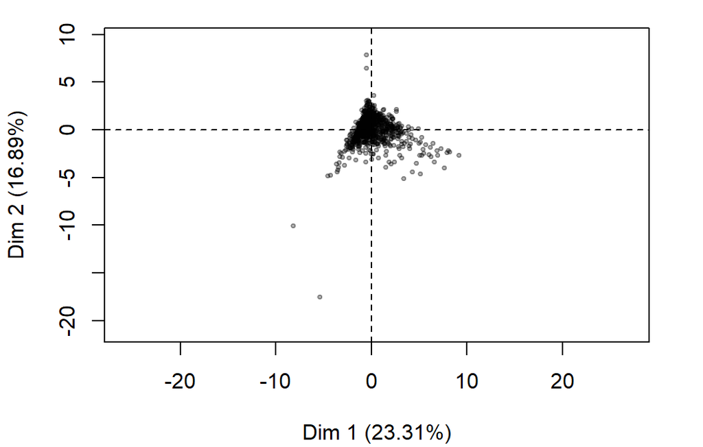

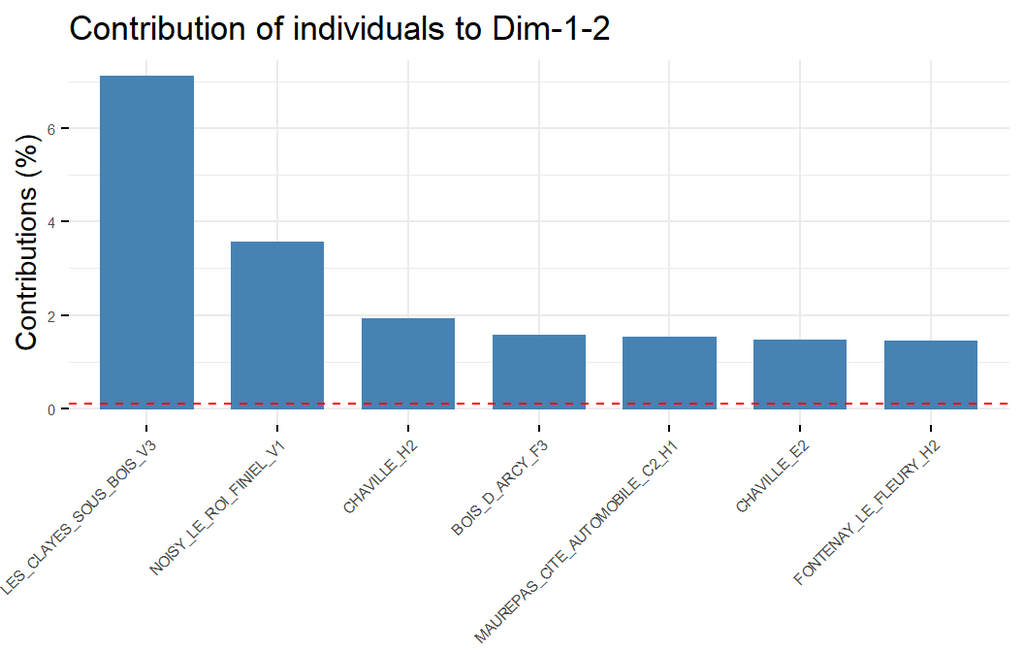

**Figure 3.1 - Graphe des cellules (ACP)** *Les cellules libellés sont ceux ayant la plus grande contribution é la construction du plan.*

On retrouve les 7 cellules qui contribuent le plus é la construction du plan. Ces cellules ont des valeurs extrémes par rapport à la moyenne cellule. On peut penser que ces cellules ont des KPI trés bon ou trés mauvais par rapport aux autres cellules.

- LES_CLAYES_SOUS_BOIS_V3
- NOISY_LE_ROI_FINIEL_V1
- CHAVILLE_H2
- BOIS_D_ARCY_F3
- MAUREPAS_CITE_AUTOMOBILE_C2_H1
- CHAVILLE_E2
- FONTENAY_LE_FLEURY_H2

Nous allons utiliser **Dimdesc()** pour décrire les dimensions. Avec la *p-value* qui correspond é la probabilité critique associée au test qui est construit. Un test sur le coefficient de corrélation entre la dimension et une variable quantitative et sur le rapport de corrélation entre la dimension et une variable qualitative. Lorsque les corrélations sont proche de 1 et la *p-value* sont proche de 0, il y a peu de chance que cette corrélation soit due au hasard, les variables sont réellement corrélées entre elles. Nous allons décrire les dimensions 1 et 2.

La dimension 1 partage :

- de fortes valeurs pour les variables DL_VOLUME_PDCP_GBYTES, VOLTE_TRAFFIC.(ERL) et UL_VOLUME_PDCP_GBYTES
- de faibles valeurs pour les variables ERAB_RETAINABILITY_%_ACT, VOLTE_RADIO_NCOUP et DL_THR_PUT_PDCP.

Lorsque les variables ou KPI volume du trafic Data et volume du trafic VoLTE sont élevés et que nous avons également des coupures data, VoLTE et le débit faible. On peut en déduire que la dimension 1 représente les cellules en congestion ou en fort trafic. Avec 23.31% on peut dire que nous avons une part importante de cellule en congestion dans notre jeu de donnée.

La dimension 2 partage :

- de fortes valeurs pour les variables DL_THR_PUT_PDCP, UL_THR_PUT_PDCP, MIMO_TX_RANK_2_RATE et INIT_ERAB_EST_SR_END_USER_WO_REP
- de faibles valeurs pour les variables VOLTE_TRAFFIC.(ERL), ERAB_RETAINABILITY_%_ACT, VOLTE_RADIO_NCOUP et UL_INTERFERENCE

Lorsque le débit data, le taux de MIMO et le taux d’accés 4G sont élevés et que nous avons également un trafic VoLTE, coupure data et interférence faible. On peut en déduire que la dimension 2 représente les cellules avec peu utilisateurs. Avec 16.89% on peut dire nous avons une grande partie des cellules en campagne qui couvrent des champs ou village. Ce qui est normal car le département 78 comprend des champs agricoles.

La meilleure variable qualitative pour illustrer les distances entre cellules sur le plan est la variable : *BANDE*.Les variables qualitatives *Secteur* ne peuvent séparer les cellules sur le plan, car elles sont unimodales.

On voit que la BANDE :

- LTE 2600 est au-dessus de l’axe
- LTE 800 est en dessous de l’axe
- LTE 2100 est é gauche et en dessous de l’axe
- LTE 1800 est é droite de l’axe

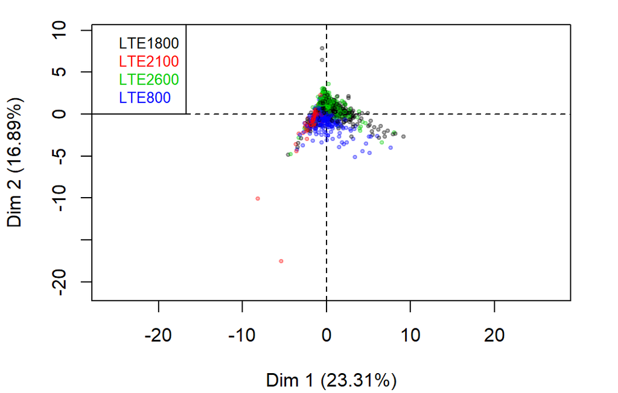

**Figure 3.2 - Graphe des cellules (ACP)** *Les cellules libellés sont ceux ayant la plus grande contribution é la construction du plan.* *Les cellules sont colorés selon leur appartenance aux modalités de la variable* BANDE.

Il est logique que la variable BANDE est représentatitif du plan 1:2 car les cellules dépendent majoritairement des Bandes de fréquences qui sont installées et de la zone (champs, ville, gare, axe routier …)

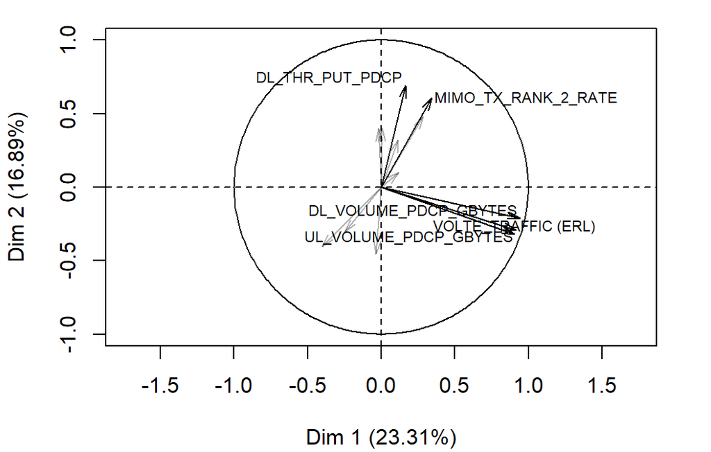

**Figure 3.3 - Graphe des variables (ACP)** *Les variables libellées sont celles les mieux représentées sur le plan.*

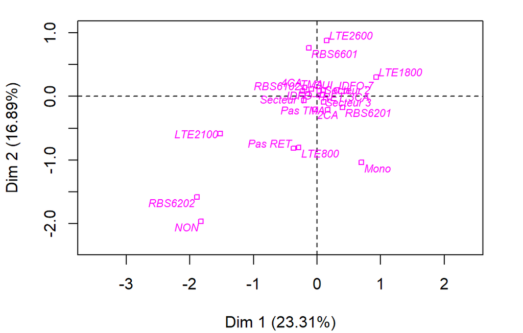

Avec le graphe des variable on remarque que les variables DL_VOLUME_PDCP_GBYTES, VOLTE_TRAFFIC.(ERL) et UL_VOLUME_PDCP_GBYTES sont trés corrélés entre eux et la dimension 1. La dimension2 est trés corrélé avec *DL_THR_PUT_PDCP* et *MIMO_TX_RANK_2_RATE*.

On peut donc dire avec les graphes des variables et des cellules que les *BANDES* :

- La LTE 2600 est caractérisée par un débit et un taux de MIMO élevé
- LTE 800 est caractérisée par un volume de trafic VOLTE, DL et UL élevé
- LTE 2100 est caractérisée par un débit et un taux de MIMO faible
- LTE 1800 est caractérisée par un débit, un taux de MIMO, un volume de trafic VOLTE, DL et UL moyen

Ce qui est logique car la bande LTE 2600, 2100 sont privilégiés dans les zone denses et urbaines avec peu de couverture, la bande LTE 800 et 1800 sont priviligiés pour couvrir de grande distance et des axes routiers ou trains.

**Figure 3.4 - Graphe des modalités (ACP)** *Les facteurs libellés sont ceux les mieux représentés sur le plan.*

On peut donc dire avec les graphes des variables et des cellules que les modalités :

Le groupe caractérisés par une coordonnée positive é droite sur l’axe partage et comprend:

- La LTE 2600, LTE 1800, IDFO7, RET et secteur 2

Le groupe caractérisés par une coordonnée négative é droite sur l’axe partage et comprend:

- La RBS6201, pas de TMA, 2CA, Mono et secteur 3

Le groupe caractérisés par une coordonnée négative é gauche sur l’axe partage et comprend:

- La RBS6202, LTE2100, non Mimo, 2CA pas de RET, LTE800 et IDFO4

Le groupe caractérisés par une coordonnée positive é gauche sur l’axe partage et comprend:

- La RBS6601, RBS6602, TMA, 4CA et secteur 1

Le groupe de variable (La RBS6201, pas de TMA, 2CA, Mono et secteur 3) est caractérisé par DL_VOLUME_PDCP_GBYTES, VOLTE_TRAFFIC (ERL) et UL_VOLUME_PDCP_GBYTES.

On peut dire que les cellules qui ont ce groupe de variable (La RBS6201, pas de TMA, 2CA, Mono et secteur 3) sont situés sur des axes routiers comme SURDENS-A13_ST_NOM_ENB1_H1 ou SURDENS_A13_NOISY_LE_ROI_H1. Ces cellules sont situés sur l’A13.

## 4. Description du plan 3:4

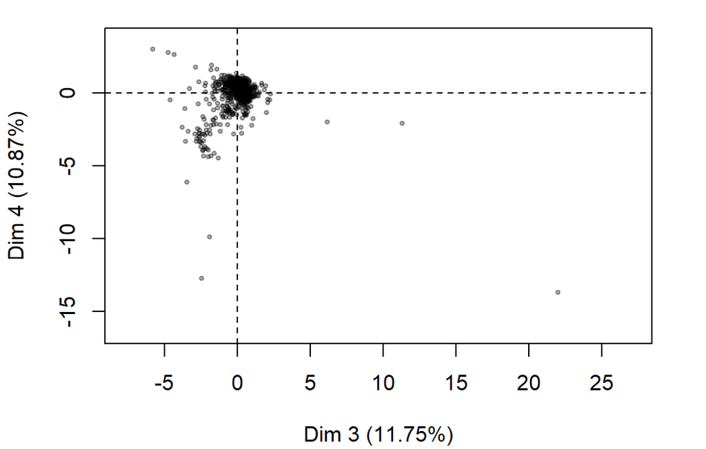

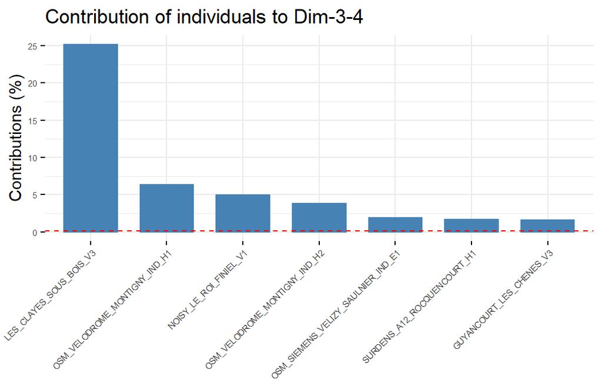

**Figure 4.1 - Graphe des cellules (ACP)** *Les cellules libellés sont ceux ayant la plus grande contribution é la construction du plan.*

On retrouve les 7 cellules qui contribuent le plus é la construction du plan 3 :4.

- LES_CLAYES_SOUS_BOIS_V3
- NOISY_LE_ROI_FINIEL_V1
- OSM_VELODROME_MONTIGNY_IND_H1
- OSM_SIEMENS_VELIZY_SAULNIER_IND_E1
- OSM_VELODROME_MONTIGNY_IND_H2
- SURDENS_A12_ROCQUENCOURT_H1
- GUYANCOURT_LES_CHENES_V3

Nous allons décrire les dimensions 3 et 4. La dimension 3 partage :

- de fortes valeurs pour les variables UL_INTERFERENCE
- de faibles valeurs pour les variables INIT_ERAB_EST_SR_END_USER_WO_REP, VOLTE_RADIO_NCOUP.

On trouve avec une forte interférence, un faible taux d’accés 4G.Ce qui logique car avoir de forte interférence provoque des dégradation sur la performance de la cellule comme le débit, une augmentation des coupures et un faible accés é la 4G. Ces interférence sont provoqué en générale par des brouilleurs extérieurs (répéteurs) ou un probléme de cablage de l’antenne. Ce qui arrivent souvent actuellement chez orange lors de mise en service mal géré par les prestataires.

La dimension 4 partage :

- de fortes valeurs pour les variables LTE_INTER_FREQ_HO_SR et DL_CA_SCHEDULED_SCELL_RATIO
- de faibles valeurs pour les variables UL_THR_PUT_PDCP

On trouve un taux de mobilité inter fréquence élevé avec un débit UL faible. Ces cellules sont souvent dégradées lorsque le paramétrage n’est pas optimisé.

La meilleure variable qualitative pour illustrer les distances entre cellules sur le plan est la variable : *topo4G*. Les variables qualitatives *Secteur* ne peuvent séparer les cellules sur le plan, car elles sont unimodales.

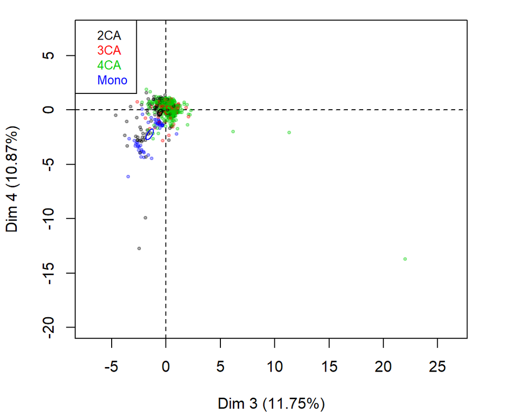

**Figure 4.2 - Graphe des cellules (ACP)** *Les cellules libellés sont ceux ayant la plus grande contribution é la construction du plan.* *Les cellules sont colorés selon leur appartenance aux modalités de la variable* topo4G.

On voit qu’avec le graphe :

- La présence de cellule Mono sur la dimension 4
- Les cellules 4CA représente la moyenne de la topologie 4G

La dimension 4 représente des cellules dégradées et qui sont caractéristique des cellule Mono car il n’y a pas assez de capacité LTE pour les besoins des utilisateurs. Et le standart actuellement chez Orange est l’installation systématique d’antenne avec les 4 bandes LTE.

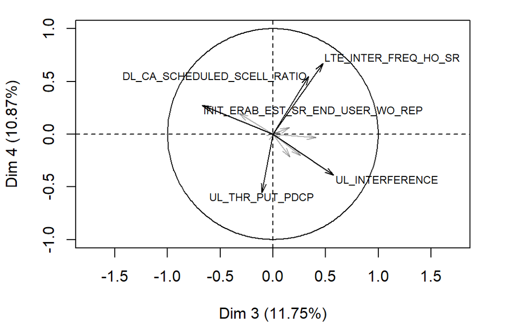

**Figure 4.3 - Graphe des variables (ACP)** *Les variables libellées sont celles les mieux représentées sur le plan.*

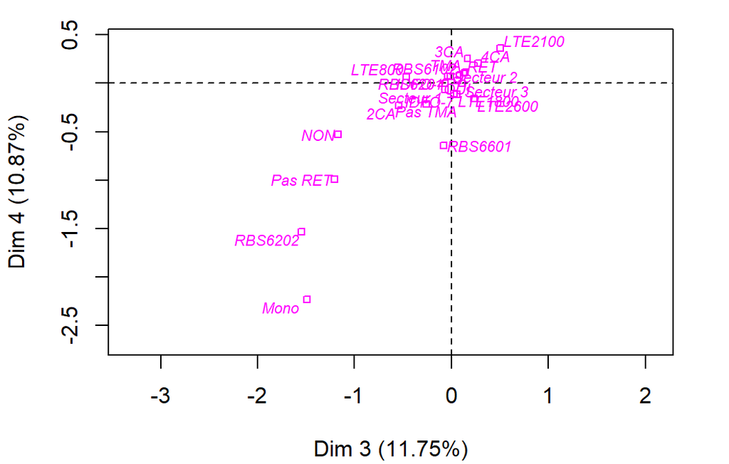

**Figure 4.4 - Graphe des modalités (ACP)** *Les facteurs libellés sont ceux les mieux représentés sur le plan.*

On peut donc dire avec les graphes des variables et des cellules que les modalités :

Le groupe caractérisés par une coordonnée positive à droite sur l’axe partage et comprend :

- La LTE 2100, RBS6102, TMA, 3CA, 4CA, IDFO4, RET et secteur 3

Le groupe caractérisés par une coordonnée négative à droite sur l’axe partage et comprend:

- LTE2600, IDFO7 et LTE1800

Le groupe caractérisés par une coordonnée négative à gauche sur l’axe partage et comprend:

- La RBS6202, pas de RET, secteur 1, Mono, 2CA, non MIMO et RBS6601

Le groupe caractérisés par une coordonnée positive à gauche sur l’axe partage et comprend:

- La LTE800, RBS6201 et secteur 2

Le groupe de variable (RBS6202, pas de RET, secteur 1, Mono, 2CA, non MIMO et RBS6601) caractérise un débit UL faible UL_THR_PUT_PDCP de la dimension 4. Le groupe correspond aux cellules situées sur les axes.

**Commentaire des dimensions 3 et 4.**

Avec le graphe des variables, on remarque que les variables LTE_INTER_FREQ_HO_SR, DL_CA_SCHEDULED_SCELL_RATIO sont trés corrélées entre eux et sont corrélées négativement avec UL_THR_PUT_PDCP. Avec une variable LTE_INTER_FREQ_HO_SR élevée proche de 100% et un taux de DL_CA_SCHEDULED_SCELL_RATIO élevé. On en déduit que les cellules sont performantes avec un de bons KPI et un débit UL_THR_PUT_PDCP performant.

On a aussi la variable UL_INTERFERENCE qui est corrélée négativement avec INIT_ERAB_EST_SR_END_USER_WO_REP. Ce qui est logique car avec un INIT_ERAB_EST_SR_END_USER_WO_REP proche de 100%. Le KPI est bon et le UL_THR_PUT_PDCP est trés élevé é -105 dBm (au lieu de -118 dBm en moyenne). par conséquence la cellule subit des dégradations.

## 5. Description de la dimension 5

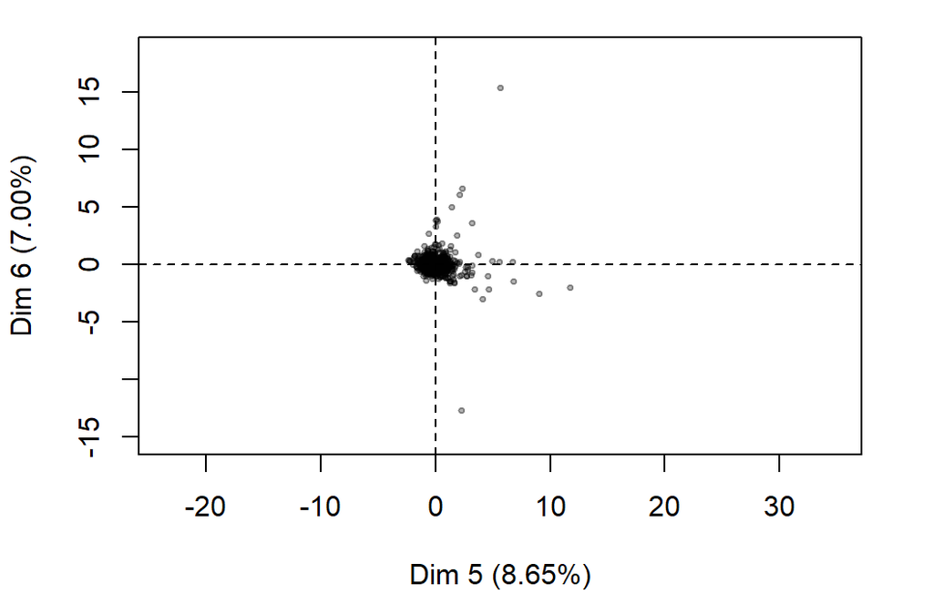

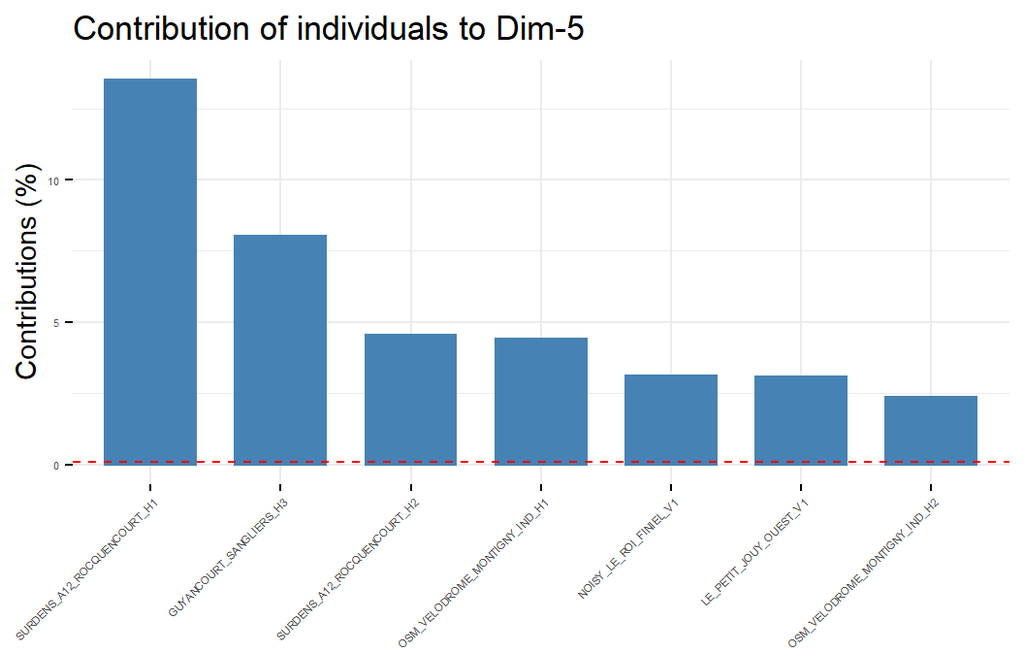

**Figure 5.1 - Graphe des cellules (ACP)** *Les cellules libellés sont ceux ayant la plus grande contribution é la construction du plan.*

On retrouve les 7 cellules qui contribuent le plus à la construction du plan 5 :6

Nous allons décrire La dimension 5

La dimension 5 partage :

- de fortes valeurs pour les variables VOLTE_RADIO_NCOUP et UL_THR_PUT_PDCP
- de faibles valeurs pour les variables INIT_ERAB_EST_SR_END_USER_WO_REP et LTE_INTRA_FREQ_HO_SR.

On trouve une forte coupure Volte et un débit UL élevé avec un accés 4G et une mobilité intra fréquence faible. Ces cellules sont souvent en congestion lors des pics d’evenements par exemple un départ de vacances, un siége social, un évenement sportif ou musical.

La meilleure variable qualitative pour illustrer les distances entre cellules sur le plan est la variable : *BANDE*. Les variables qualitatives *Secteur* ne peuvent séparer les cellules sur le plan, car elles sont unimodales.

On voit que la BANDE :

- LTE 2600 est au-dessus et é droite de l’axe
- LTE 800 est en dessous et é gauche de l’axe
- LTE 2100 est é gauche et en dessus de l’axe
- LTE 1800 est au centre

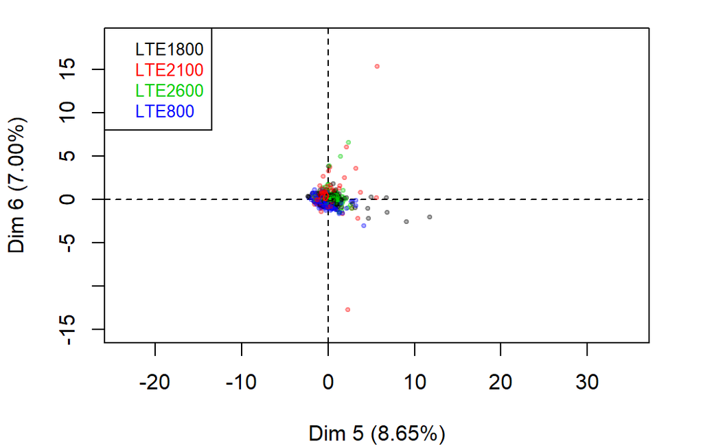

**Figure 5.2 - Graphe des cellules (ACP)** *Les cellules libellés sont ceux ayant la plus grande contribution é la construction du plan.* *Les cellules sont colorés selon leur appartenance aux modalités de la variable* BANDE.

Il est logique que la variable BANDE est représentatitif du plan 5:6 car les cellules dépendent toujours des Bandes de fréquences qui sont installées et de la zone (champs, ville, gare, axe routier .)

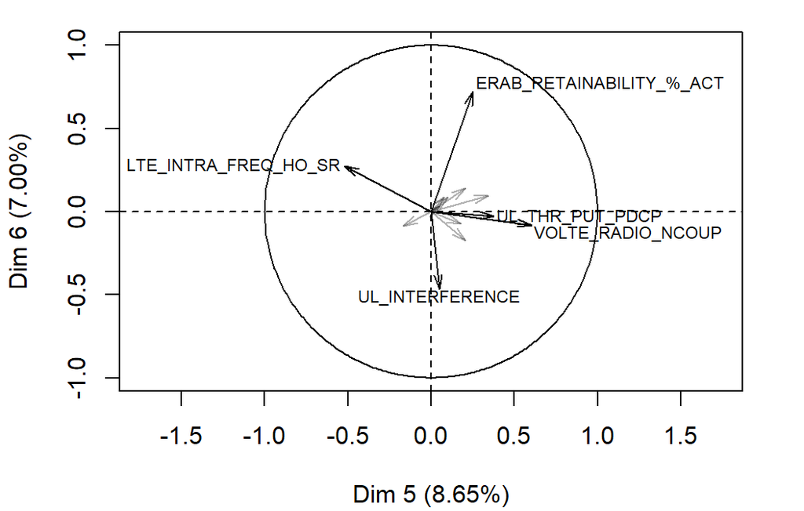

**Figure 5.3 - Graphe des variables (ACP)** *Les variables libellées sont celles les mieux représentées sur le plan.*

Avec le graphe des variable on remarque que les UL_THR_PUT_PDCP, VOLTE_NCOUP sont trés corrélés entre eux et sont corrélées négativement avec LTE_INTRA_FREQ_HO_SR. Cela est curieux de voir que le débit UL est corrélé avec le nombre de coupure VoLTE. On peut supposer que lorsqu’on a un débit UL faible on a de forte chance répondre au téléphone en envoyant sa voix ce qui provoque beaucoup de coupure VoLTE par manque de ressource. La dimension 5 est trés corrélé avec les variables UL_THR_PUT_PDCP et VOLTE_NCOUP. On peut donc dire avec les graphes des variables et des cellules que les *BANDES* de type :

- LTE 2600 est caractérisée par un débit et un taux de MIMO élevé
- LTE 800 est caractérisée par un volume de trafic VOLTE, DL et UL élevé
- LTE 2100 est caractérisée par un débit et un taux de MIMO faible
- LTE 1800 est caractérisée par un débit, un taux de MIMO, un volume de trafic VOLTE, DL et UL moyen

Ce qui est logique car la bande LTE 2600, 2100 sont privilégiés dans les zone denses et urbaines avec peu de couverture, la bande LTE 800 et 1800 sont priviligiés pour couvrir de grande distance et des axes routiers ou trains. On retrouve les mémes résultats que sur le plan 1:2.

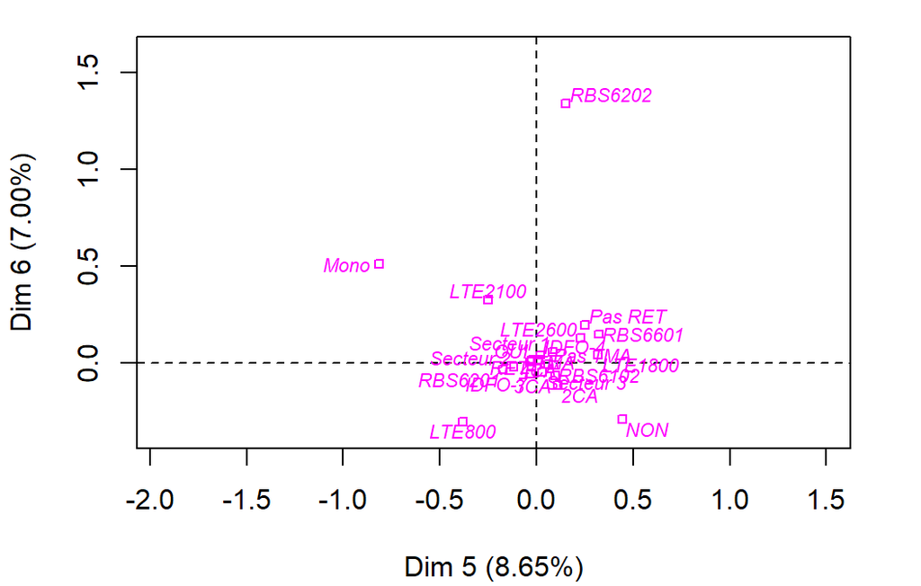

**Figure 5.4 - Graphe des modalités (ACP)** *Les facteurs libellés sont ceux les mieux représentés sur le plan.*

On peut donc dire avec les graphes des variables et des cellules que les modalités. Le groupe caractérisés par une coordonnée positive à droite sur l’axe partage et comprend :

- La LTE 2600, RBS6202, 2CA, IDFO4, Pas RET, secteur 1 et LTE 1800

Le groupe caractérisés par une coordonnée négative à droite sur l’axe partage et comprend:

- RBS6102, RET et secteur3

Le groupe caractérisés par une coordonnée négative à gauche sur l’axe partage et comprend:

- Pas de TMA, LTE800, IDFO7, secteur2 et RBS6201

Le groupe caractérisés par une coordonnée positive à gauche sur l’axe partage et comprend:

- La LTE2100, Mono et TMA

Les 4 groupes sont tous au centre et on ne peut pas les dissocier. Ce qui veut dire que les cellules ont un peu prés similaire avec les dimensions 5 et 6.

**Pour conclure sur l’ACP.**

# 4.Classification

On veut regrouper les 906 cellules du tableau de données en quelques groupes correspondant é différents profils de cellules LTE. Pour cela il existe plusieurs méthodes de classification. La méthode de partitionnement aussi appelée méthode des k-means ou agrégation autour des centres mobiles, la méthode ascendante hiérarchiques (CAH) et les méthodes mixtes. La méthode par K-MEANS, é la différence de la CAH, ne fournit pas d’outil d’aide à la détection du nombre de groupes. Dans cette partie nous allons analyser notre jeu de donnée avec la méthode CAH et k-means.

## 6.Classification ascendante hiérarchique CAH

On compléte l’analyse des composantes de l’ACP avec une CAH. Pour cela, on retient les premiéres composantes telles que l’inertie cumulée atteigne 40%

Pour le CAH on va utiliser le critére de Ward. La method = ward.D2 correspond au vrai critére de Ward.

Le calcul de l’inertie inter-classe nous designe 5 groupes.

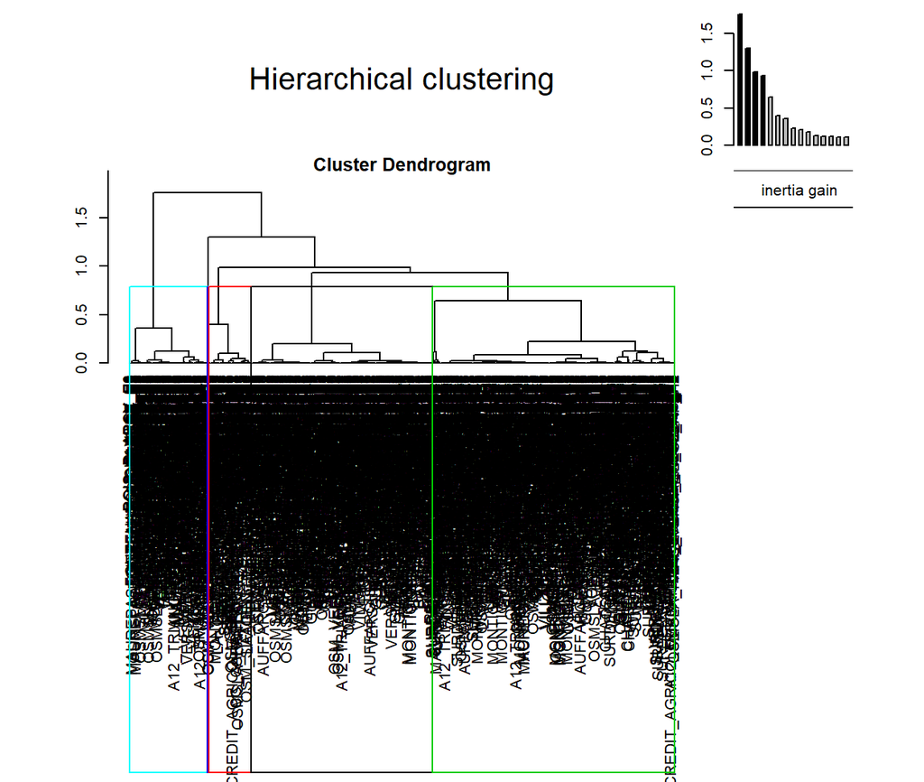

Le dendrogramme à suggére à aussi un découpage en 5 groupes. On note qu’une groupe de cellules tout é gauche se démarque fortement des autres au point et qu’on aurait pu envisager aussi un découpage en 2 groupes seulement.

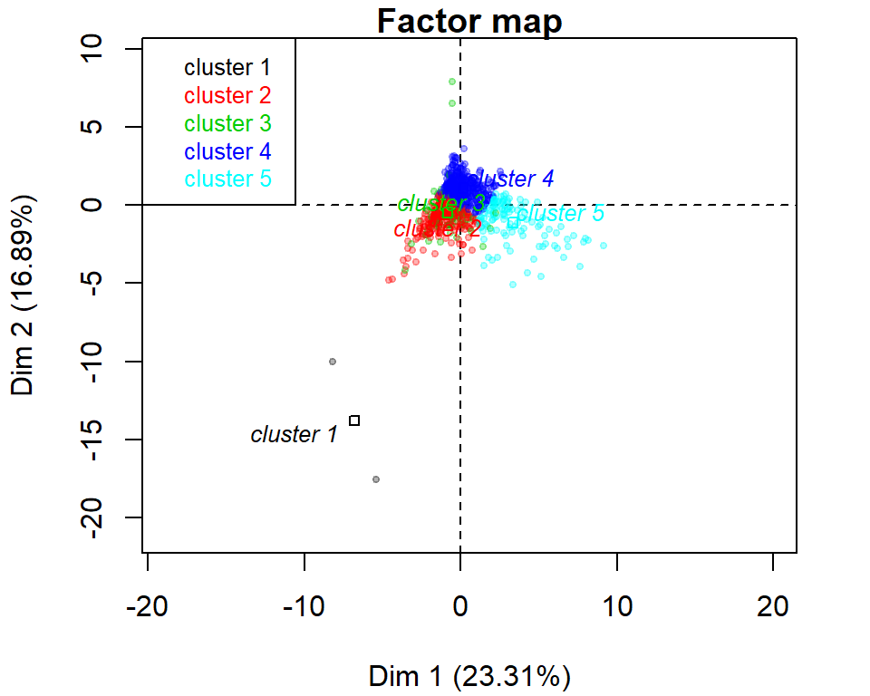

**Figure 6 - Classification Ascendante Hiérachique des cellules.**

On remarque que la groupe 1 se démarque par rapport aux autres groupes et la groupe 3 se situe au milieu des groupes 2, 4 et 5.

*La classification réalisée sur les cellules fait apparaétre 5 groupes.*

Le groupe 1 est composé de cellules partageant :

- de fortes valeurs pour la variable UL_INTERFERENCE.
- de faibles valeurs pour les variables INIT_ERAB_EST_SR_END_USER_WO_REP, MIMO_TX_RANK_2_RATE, DL_CA_SCHEDULED_SCELL_RATIO et DL_THR_PUT_PDCP (de la plus extréme é la moins extréme).

On peut en déduire que les cellules ont des problémes d’interférence. Ces interférences provoquent des débits, taux de MIMO et des accés en 4G faible. Ces cellules sont représentés par NOISY_LE_ROI_FINIEL_V1 et LES_CLAYES_SOUS_BOIS_V3 qui sont caractéristique de la BANDE L2100. La bande 2100 est une nouvelle fréquence en LTE et a été active en novembre 2018. Ce qui peut etre la conséquence de problémes de configurations ou de paramétrages.

Le groupe 2 est composé de cellules partageant :

- de fortes valeurs pour les variables *ERAB_RETAINABILITY_%_ACT, VOLTE_RADIO_NCOUP* et LTE_INTER_FREQ_HO_SR.
- de faibles valeurs pour les variables DL_THR_PUT_PDCP, MIMO_TX_RANK_2_RATE, DL_VOLUME_PDCP_GBYTES, UL_VOLUME_PDCP_GBYTES, VOLTE_TRAFFIC.(ERL), UL_THR_PUT_PDCP et LTE_INTRA_FREQ_HO_SR.

On peut en déduire que ces cellules ont des taux de coupure 4G élevés. Ce qui provoquent des débits,un volume de trafic et un taux de MIMO faible. Ces cellules sont représentés par ROUTE_ST_MARTIN_A86_F1, GUYANCOURT_ZA_V1, VERSAILLES_REINE_SIMON_F3 et ST_CYR_PARC_H2. Ces cellules sont essentielles situés prés des axes routiers et dans les zones faiblement couvert par par rapport é la population.

Le groupe 3 est composé de cellules partageant :

- de fortes valeurs pour les variables UL_THR_PUT_PDCP et MIMO_TX_RANK_2_RATE
- de faibles valeurs pour les variables LTE_INTER_FREQ_HO_SR et DL_CA_SCHEDULED_SCELL_RATIO

On peut en déduire que ces cellules ont des des mobilités inter fréquence et taux de CA faible. Ce qui est le signe de cellules dégradées avec des problémes de paramétrages et matériel. Ces cellules sont représentés par MONTIGNY_ZI_F2, ETANG_SEC_F2, TRAPPES_ZI_F1 et CREDIT_AGRICOLE_SQYPARK_GUYANCOURT_IND_E1. Ces cellules sont essentielles situés mi-urbain.

Le groupe 4 est composé de cellules partageant :

- de fortes valeurs pour les variables DL_THR_PUT_PDCP, MIMO_TX_RANK_2_RATE, DL_CA_SCHEDULED_SCELL_RATIO, LTE_INTER_FREQ_HO_SR et INIT_ERAB_EST_SR_END_USER_WO_REP.
- de faibles valeurs pour les variables VOLTE_TRAFFIC.(ERL), *ERAB_RETAINABILITY_%_ACT, UL_VOLUME_PDCP_GBYTES, VOLTE_RADIO_NCOUP* et DL_VOLUME_PDCP_GBYTES.

On peut en déduire que ces cellules ont des débits, MIMO, taux de CA et mobilités inter fréquence élevés et avec un trafic VoLTE, coupure data et VoLTE, trafic data faible. Ce qui signifie des cellules en bon état. Ces cellules sont représentés par LES_CLAYES_SOUS_BOIS_E2, LES_ESSARTS_EU_E1 etLA_CLAIRIERE_H2. Ces cellules sont caractéristique de la BANDE L2600. La Bande L2600 est la fréquence privilégiée lorsqu’un mobile se connecte sur le réseau d’Orange avec de bonne condition radio.

Le groupe 5 est composé de cellules partageant :

- de fortes valeurs pour les variables DL_VOLUME_PDCP_GBYTES, VOLTE_TRAFFIC. (ERL), UL_VOLUME_PDCP_GBYTES et LTE_INTER_FREQ_HO_SR.
- de faibles valeurs pour la variable *ERAB_RETAINABILITY_%_ACT*.

On peut en déduire que les cellules ont des mobilités inter fréquence, un trafic VoLTE, un volume de trafic data élevés et un faible pourcentage de coupure 4G. Ces cellules sont essentielles situées dans des zones avec trés peuplées comme des centres villes (VERSAILLES_HONORE_H1) ou des noeuds routiers (PLAINE_DE_JARDY_BIS_H2, LA_VERRIERE_F3, ROCQUENCOURT_BIS_H1).

Avec la methode CAH nous avons trouvé 5 groupes de cellules. Maintenant nous allons classifier le jeu de donnée avec la méthode des kmeans et voir combien de groupe nous allons trouver.

## 7.Classification K-MEANS

Nous allons commencer par regrouper les données en deux groupes (centers = 2). L’algorithme Kmeans a également une option nstart qui multiples les configurations initiales et propose le meilleur. Dans ce cas, nstart = 25 et on générera 25 configurations initiales.

Nous ne connaissons pas le nombres optimum de groupe pour le jeu de donnée avec la méthode kmeans. pour cela nous allons calculer plusieurs valeurs différentes de k et d’examiner les différents résultats. K représente le nombre de groupe et nous allons calculer pour 3, 4 et 5 groupes. Les résultats représentés dans la figure sont :

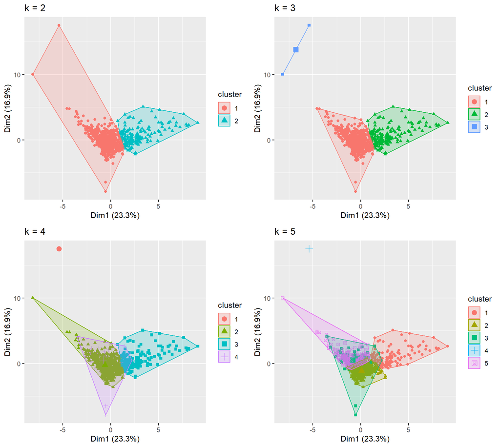

Bien que ces différents diagrammes nous indique oé se produisent de véritables dilemme entre les groupes, elles ne nous disent pas quel est le nombre optimal de groupes pour ce jeu de donnée.

### Optimisation du nombre de groupes

Pour trouver le nombre de groupes à utiliser. Il est préférable que le nombre de groupe soit optimal. Pour m’aider dans l’analyse, voici les trois méthodes les plus populaires pour déterminer les groupes optimales et qu’on va utiliser pour la méthode kmeans:

**1.Méthode “Elbow”**

**2.Méthode “Silhouette”**

**3.Méthode Gap Statistic**

### 1.Méthode Elbow

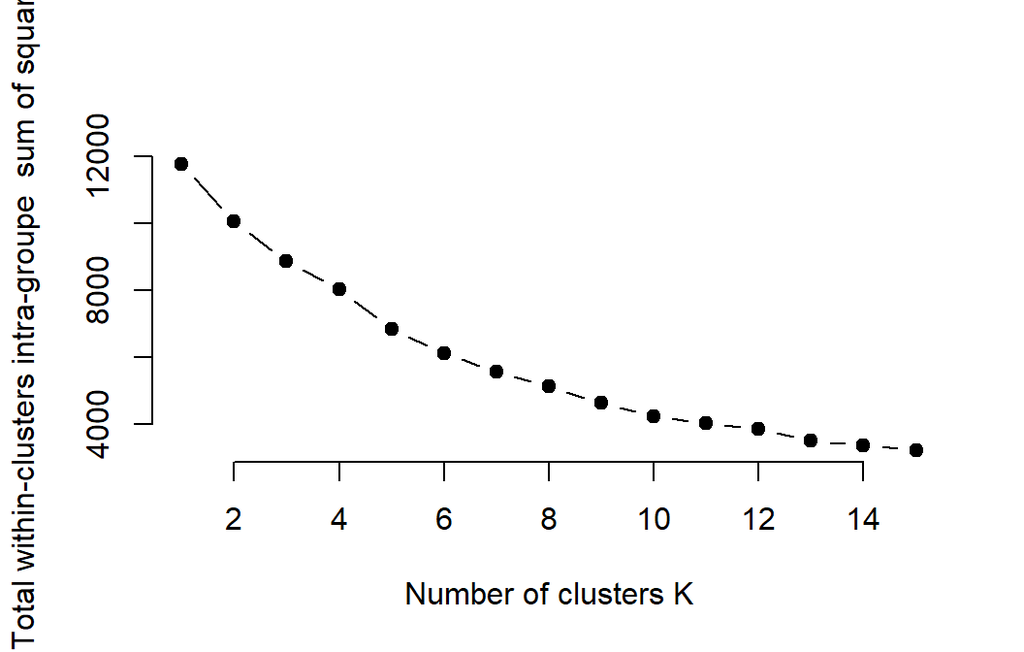

En utilisant la fonction **fviz_nbclust** avec la methode within-clusters sum of squares ou intra-classe (wss) on a:

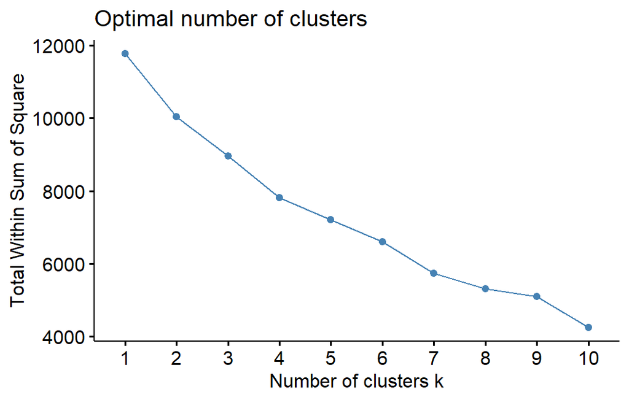

Les résultats suggérent que le nombre optimal de groupe est 5.

### 2.Méthode Silhouette

Avec la méthode de la silhouette moyenne, nous allons mesurer la qualité d’un regroupement.

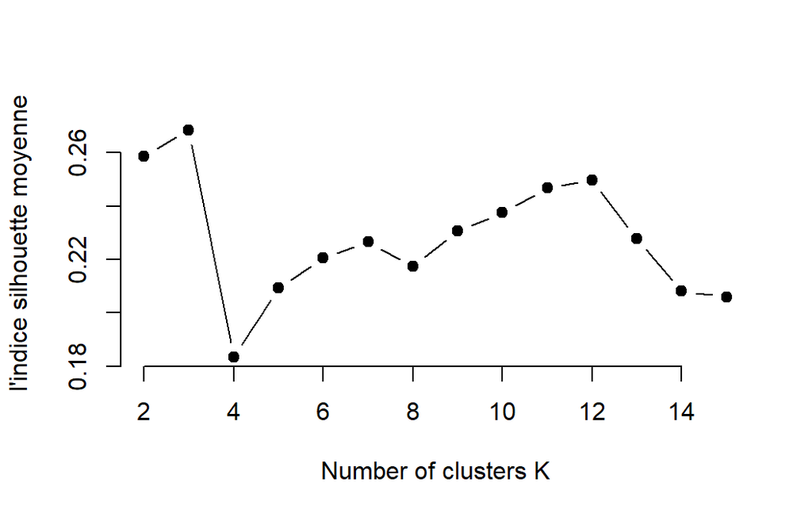

En utilisant la fonction **fviz_nbclust** avec la methode silhouette on a:

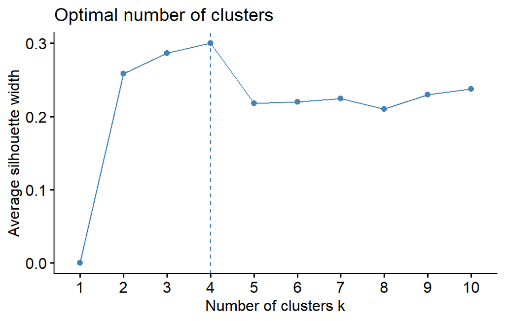

Les résultats montrent que 3 groupes maximisent les valeurs moyennes de la méthode silhouette mais on a aussi 4 groupes en deuxiéme choix pour le nombre optimal de groupes.

### 3.Méthode Gap Statistic

Pour calculer avec la méthode Gap Statistic (statistique de l’écart), nous pouvons utiliser la fonction clusGap.

```
## Clustering Gap statistic ["clusGap"] from call:
## clusGap(x = df, FUNcluster = kmeans, K.max = 10, B = 50, nstart = 25)
## B=50 simulated reference sets, k = 1..10; spaceH0="scaledPCA"
##  --> Number of clusters (method 'firstmax'): 2
##           logW   E.logW      gap      SE.sim
##  [1,] 6.846656 8.590558 1.743902 0.005238992
##  [2,] 6.741799 8.497882 1.756082 0.004931944
##  [3,] 6.719011 8.434647 1.715637 0.005036169
##  [4,] 6.627758 8.387438 1.759680 0.005162869
##  [5,] 6.554451 8.350979 1.796528 0.004419805
##  [6,] 6.519096 8.319298 1.800203 0.004432772
##  [7,] 6.495637 8.296637 1.801000 0.004122122
##  [8,] 6.475414 8.276917 1.801503 0.004299099
##  [9,] 6.404658 8.263726 1.859068 0.004162584
## [10,] 6.379357 8.251716 1.872359 0.004037040
```

Nous pouvons visualiser les résultats avec **fviz_gap_stat** qui suggére 2 groupes comme nombre optimal de groupes.

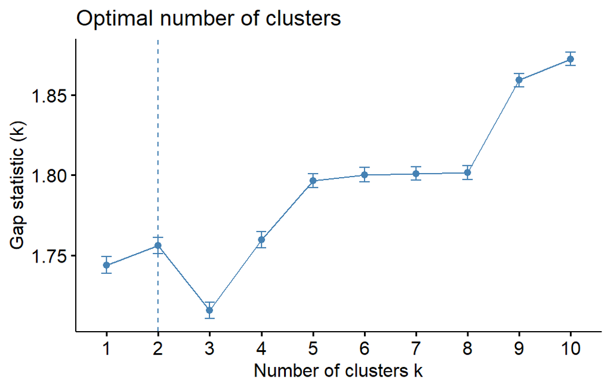

Avec la plupart de ces approches suggérent 5, 3, 5 ou 2 nombre optimal de groupes. Nous pouvons faire la moyenne des nombre de groupes et effectuer l’analyse finale en utilisant 4 groupes.

Nous pouvons visualiser le résultat avec la fonction **fviz_cluster**.

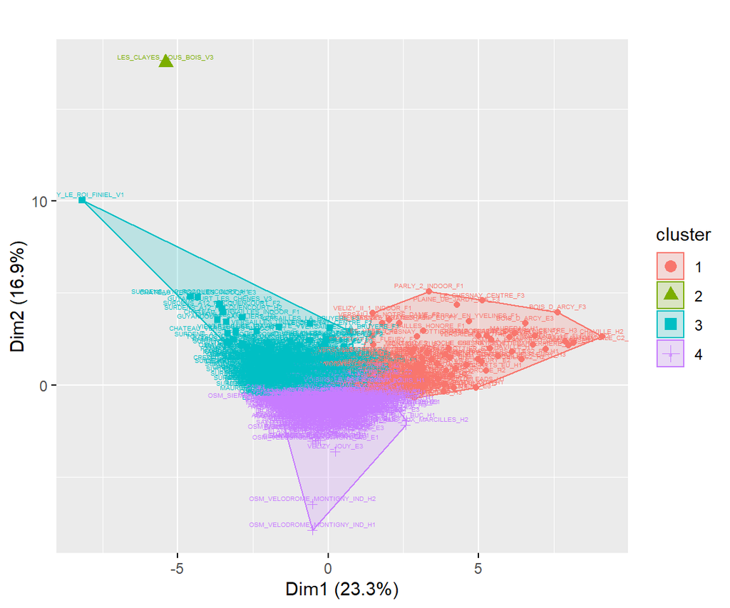

**Figure 7 - Classification K-means optimal.** *La classification réalisée sur les cellules fait apparaétre 4 groupes.*

*Le groupe 1* est composé de cellules avec un VOLTE_TRAFFIC, DL_VOLUME_PDCP_GBYTES et UL_VOLUME_PDCP_GBYTES élevés. Ces cellules sont représenté par BOIS_D_ARCY_F3, BULL_EU_E3 et CELLE_ST_CLOUD_H2. Ce sont des cellules importantes dans des zones é haut trafic.

*Le groupe 4* est composé de cellules avec un DL_CA_SCHEDULED_SCELL_RATIO, UL_THR_PUT_PDCP et un MIMO_TX_RANK_2_RATE élevé. Ces cellules sont représenté par ETANG_SEC_E1 FONTENAY_LE_FLEURY_E1 GUYANCOURT_BOUVIERS_E1. Ce sont des cellules qui sont optimales.

Avec la methode Kmeans nous avons trouvé 4 groupes de cellules qui représentent bien les differents états d’une cellule en service sur le réseau mobile d’Orange.

On s’interroge sur le cas du groupe 3 du CAH afin de savoir s’il est utile pour classifer les cellules. A mon avis avec un jeu de cellules plus conséquent, nous pouvons justifier le cas de 5 groupes pour classifier le jeu de donnée car il y a de multitudes d’état de cellule comme en centre urbain avec de la congestion, sur les axes routier ou train avec des problémes de mobilité, en pleine campagne avec des faible débit etc…

# 5.Conclusion

Avec l’ACP, la visualisation des observations dans des plans de 1 :5 a permis d’identifier des cellules atypiques comme les cellules LES_CLAYES_SOUS_BOIS_V3, NOISY_LE_ROI_FINIEL_V1, OSM_VELODROME_MONTIGNY_IND_H2 et SURDENS_A12_ROCQUENCOURT_H1. En revenant aux données brutes, ces cellules ont des variables quantitatifs extrémes par rapport à la moyenne et qui confirme leurs cas atypiques. En utilisant les variables qualitatifs supplémentaires, on visualise aussi que la BANDE 2100 et la topologie 4G Mono caractérise le débit et le taux MIMO faible. Les autres indicateurs n’ont pas d’impact sur les variables KPI. Enfin la classification nous montre 5 catégories de cellules qui partagent les mémes attributs. Dans les groupes 1 et 2 du CAH on retrouve les cellules atypiques de l’ACP. Pour répondre aux problématiques en introduction on peut dire que:

Les cellules n’ont pas la méme activité et dépendent de la zone ou elles sont situées et de leur bande de fréquence. Nous avons aussi plusieurs type de cellules avec une grande partie en congestion (dimension 1 avec 23.31% d’inertie). Avec la classification, nous pouvons regrouper les cellules par rapport à leurs états de fonctionnement (dégradé, congestioné, performant, à optimiser ou à réparer). Avec cette analyse, on peut voir les configurations (variable qualitative) qui ont souvent un fonctionnement dégradé.

Grace à cette analyse, nous avons pu détecter les cellules et les variables (KPI) dégradées. Ainsi, en prenant les données sur 2 ou 3 ans avec des techniques de prédiction, on peut prédire le comportement de ces cellules.

# 6.Annexes

```r
head(final$cluster)
```

```
A12_TRIANGLE_DE_ROCQUENCOURT_F1 A12_TRIANGLE_DE_ROCQUENCOURT_F2
                              3                               1
A12_TRIANGLE_DE_ROCQUENCOURT_F3 A12_TRIANGLE_DE_ROCQUENCOURT_H1
                              3                               4
A12_TRIANGLE_DE_ROCQUENCOURT_H2 A12_TRIANGLE_DE_ROCQUENCOURT_H3
                              1                               3
```

```r
final$centers
```

```
  LTE_INTRA_FREQ_HO_SR LTE_INTER_FREQ_HO_SR ERAB_RETAINABILITY_%_ACT
1            0.0825796            0.1656383               -0.2654709
2           -0.4501058            0.3033208               -0.4348895
3           -0.2020637           -0.2302768                0.3211330
4            0.1939482            0.1913898               -0.2536674
  UL_INTERFERENCE INIT_ERAB_EST_SR_END_USER_WO_REP DL_THR_PUT_PDCP
1      0.12108390                        0.1604495      -0.1343721
2     28.11779270                      -19.2605926      -2.0961652
3     -0.02438285                       -0.1464131      -0.7633854
4     -0.09675527                        0.1541669       0.9047333
  VOLTE_RADIO_NCOUP VOLTE_TRAFFIC (ERL) DL_VOLUME_PDCP_GBYTES
1       -0.14170052           1.8412282             1.8126621
2       -0.08428583          -0.3371288            -0.8423921
3        0.23995534          -0.4137853            -0.4981758
4       -0.21190452          -0.2447331            -0.1387130
  UL_VOLUME_PDCP_GBYTES UL_THR_PUT_PDCP MIMO_TX_RANK_2_RATE
1             1.8081441      -0.1391986           0.1575489
2            -0.7976433      -0.7037467          -2.8062413
3            -0.4510504      -0.2062543          -0.6030444
4            -0.1894245       0.2842227           0.6168976
  DL_CA_SCHEDULED_SCELL_RATIO
1                 -0.21632083
2                 -2.91794218
3                 -0.09774618
4                  0.19938911
```

```r
res.hcpc$desc.var
```

```
Link between the cluster variable and the categorical variables (chi-square test)
=================================================================================
             p.value df
BANDE  1.258118e-112 12
topo4G  4.247956e-43 12
MIMO    3.405076e-15  4
RET     3.767030e-15  4
RBS     2.552704e-06 12
TMA     8.411949e-05  4
PLAQUE  5.302172e-03  4

Description of each cluster by the categories
=============================================
$`1`
               Cla/Mod Mod/Cla   Global   p.value   v.test
BANDE=LTE2100 1.574803     100 14.01766 0.0195163 2.335519

$`2`
               Cla/Mod   Mod/Cla    Global      p.value     v.test
BANDE=LTE2100 93.70079 33.711048 14.017660 8.316479e-45  14.044576
BANDE=LTE800  64.49275 50.424929 30.463576 3.689227e-25  10.362062
topo4G=4CA    44.80769 66.005666 57.395143 2.686435e-05   4.198538
PLAQUE=IDFO-4 43.27808 66.572238 59.933775 1.099092e-03   3.263850
MIMO=NON      62.22222  7.932011  4.966887 1.378726e-03   3.199068
topo4G=3CA    29.81366 13.597734 17.770419 8.141552e-03  -2.646142
MIMO=OUI      37.74681 92.067989 95.033113 1.378726e-03  -3.199068
PLAQUE=IDFO-7 32.50689 33.427762 40.066225 1.099092e-03  -3.263850
topo4G=Mono   14.28571  1.983003  5.408389 1.318553e-04  -3.822967
BANDE=LTE1800 12.64822  9.065156 27.924945 1.760420e-26 -10.649109
BANDE=LTE2600  9.60000  6.798867 27.593819 6.611665e-33 -11.948489

$`3`
                Cla/Mod   Mod/Cla    Global      p.value    v.test
topo4G=Mono   46.938776 40.350877  5.408389 3.987220e-17  8.413274
BANDE=LTE800  14.855072 71.929825 30.463576 3.452450e-11  6.625855
RET=Pas RET   25.882353 38.596491  9.381898 5.109149e-10  6.215715
MIMO=NON      28.888889 22.807018  4.966887 1.076530e-06  4.877107
topo4G=2CA    14.772727 45.614035 19.426049 3.526442e-06  4.637503
TMA=Pas TMA   11.111111 61.403509 34.768212 2.632757e-05  4.203107
RBS=RBS6202   40.000000  7.017544  1.103753 2.394061e-03  3.036419
```

[output cut: 149 more lines]

```
DL_VOLUME_PDCP_GBYTES       22.895130      489.8602568  145.4401849
LTE_INTER_FREQ_HO_SR         2.874643       98.3651351   92.3692968
Secteur                      2.046405        2.0173913    1.8752759
MIMO_TX_RANK_2_RATE          1.965973       46.0051319   43.3584510
ERAB_RETAINABILITY_%_ACT    -2.876709        0.0451934    0.1066782
DL_CA_SCHEDULED_SCELL_RATIO -3.534936       37.3493417   41.7570164
                            sd in category  Overall sd       p.value
UL_VOLUME_PDCP_GBYTES          11.53682544   8.8994413 3.533343e-118
VOLTE_TRAFFIC.(ERL)           104.35500218  90.8468928 1.486485e-117
DL_VOLUME_PDCP_GBYTES         208.48646439 172.5560930 5.195317e-116
LTE_INTER_FREQ_HO_SR            3.62902739  23.9249479  4.044848e-03
Secteur                         0.76876647   0.7965892  4.071653e-02
MIMO_TX_RANK_2_RATE            12.17726616  15.4421917  4.930170e-02
ERAB_RETAINABILITY_%_ACT        0.04626381   0.2451642  4.018466e-03
DL_CA_SCHEDULED_SCELL_RATIO    16.67103018  14.3025334  4.078742e-04
```

```r
res.hcpc$desc.ind
```

```
$para
Cluster: 1
 NOISY_LE_ROI_FINIEL_V1 LES_CLAYES_SOUS_BOIS_V3
               8.997041                8.997041
--------------------------------------------------------
Cluster: 2
   ROUTE_ST_MARTIN_A86_F1            ST_CYR_PARC_H2
                0.3902249                 0.4148353
   NEAUPHLE_MOULIN_BIS_V2          GUYANCOURT_ZA_V1
                0.4229171                 0.4543041
VERSAILLES_REINE_SIMON_F3
                0.4733944
--------------------------------------------------------
Cluster: 3
                           MONTIGNY_ZI_F2
                                0.7464492
                             ETANG_SEC_F2
                                1.0809679
                            TRAPPES_ZI_F1
                                1.1162222
CREDIT_AGRICOLE_SQYPARK_GUYANCOURT_IND_E1
                                1.1344015
                            TRAPPES_ZI_F2
                                1.1366382
--------------------------------------------------------
Cluster: 4
 LES_CLAYES_SOUS_BOIS_E2        LES_ESSARTS_EU_E1          LA_CLAIRIERE_H2
               0.2597751                0.2739504                0.2845789
  OSMSLA_PLAISIR_EADS_E3 OSMSLA_ST_CYR_CNRA_RF_E2
               0.2941857                0.3065720
--------------------------------------------------------
Cluster: 5
PLAINE_DE_JARDY_BIS_H2         LA_VERRIERE_F3   VERSAILLES_HONORE_H1
             0.6161094              0.6765551              0.7042977
   ROCQUENCOURT_BIS_H1            CHAVILLE_F2
             0.7579419              0.7932498

$dist
Cluster: 1
LES_CLAYES_SOUS_BOIS_V3  NOISY_LE_ROI_FINIEL_V1
```

[output cut: 18 more lines]

```
Cluster: 4
               VELIZY_JOUY_E3       ELANCOURT_ROND_POINT_E2
                     5.468029                      4.838384
                VILLEPREUX_E1 OSM_VELODROME_MONTIGNY_IND_E1
                     4.810388                      4.767735
            COIGNIERES_SUD_H1
                     4.668041
--------------------------------------------------------
Cluster: 5
                   CHAVILLE_H2                 BOIS_D_ARCY_F3
                      9.743283                       9.102901
MAUREPAS_CITE_AUTOMOBILE_C2_H1                    CHAVILLE_E2
                      8.710611                       8.521787
         FONTENAY_LE_FLEURY_H2
                      8.498655
```

```r
dimdesc(res,axes = 1:2, proba = 1e-05)
```

```
$Dim.1
$Dim.1$quanti
                                 correlation      p.value
DL_VOLUME_PDCP_GBYTES              0.9433167 0.000000e+00
UL_VOLUME_PDCP_GBYTES              0.9172681 0.000000e+00
VOLTE_TRAFFIC (ERL)                0.9054400 0.000000e+00
MIMO_TX_RANK_2_RATE                0.3412856 3.782458e-26
INIT_ERAB_EST_SR_END_USER_WO_REP   0.2857646 1.736919e-18
DL_THR_PUT_PDCP                    0.1652233 5.711203e-07
VOLTE_RADIO_NCOUP                 -0.2471413 4.488284e-14
ERAB_RETAINABILITY_%_ACT          -0.4033879 8.968753e-37

$Dim.1$quali
               R2      p.value
BANDE  0.19757712 8.233808e-43
MIMO   0.05750252 2.576384e-13
RBS    0.04375143 8.871031e-09
topo4G 0.02870923 8.295817e-06

$Dim.1$category
                Estimate      p.value
BANDE=LTE1800  1.1118444 8.755003e-25
MIMO=OUI       0.9606013 2.576384e-13
RBS=RBS6201    0.8642745 2.690263e-08
RBS=RBS6102    0.2302834 6.636682e-06
MIMO=NON      -0.9606013 2.576384e-13
BANDE=LTE2100 -1.3418774 4.358704e-28


$Dim.2
$Dim.2$quanti
                                 correlation       p.value
DL_THR_PUT_PDCP                    0.6923599 2.864085e-130
MIMO_TX_RANK_2_RATE                0.6060815  5.902322e-92
INIT_ERAB_EST_SR_END_USER_WO_REP   0.4801928  1.928894e-53
UL_THR_PUT_PDCP                    0.3999680  3.976046e-36
DL_CA_SCHEDULED_SCELL_RATIO        0.3968607  1.515445e-35
LTE_INTRA_FREQ_HO_SR               0.3180189  9.700748e-23
DL_VOLUME_PDCP_GBYTES             -0.2107039  1.499361e-10
UL_VOLUME_PDCP_GBYTES             -0.2921606  2.745846e-19
```

[output cut: 8 more lines]

```
MIMO   0.09154814 1.232378e-20
RET    0.03133987 8.155357e-08
topo4G 0.03586338 3.281800e-07
RBS    0.03142205 2.450945e-06

$Dim.2$category
                Estimate      p.value
BANDE=LTE2600  0.9280283 5.782204e-30
MIMO=OUI       1.0317247 1.232378e-20
RET=RET        0.4497949 8.155357e-08
BANDE=LTE2100 -0.5304864 1.602157e-06
topo4G=Mono   -0.7858773 3.793301e-07
RET=Pas RET   -0.4497949 8.155357e-08
MIMO=NON      -1.0317247 1.232378e-20
BANDE=LTE800  -0.7541847 4.234685e-29
```

```r
dimdesc(res,axes = 3:4, proba = 1e-05)
```

```
$Dim.3
$Dim.3$quanti
                                 correlation       p.value
UL_INTERFERENCE                    0.5778036  8.194146e-82
LTE_INTER_FREQ_HO_SR               0.4755895  2.563130e-52
LTE_INTRA_FREQ_HO_SR               0.4078377  1.258532e-37
DL_CA_SCHEDULED_SCELL_RATIO        0.3391902  7.887758e-26
MIMO_TX_RANK_2_RATE                0.2598349  1.909589e-15
DL_THR_PUT_PDCP                    0.1620736  9.385139e-07
ERAB_RETAINABILITY_%_ACT           0.1552527  2.664415e-06
VOLTE_RADIO_NCOUP                 -0.3212989  3.341519e-23
INIT_ERAB_EST_SR_END_USER_WO_REP  -0.6726242 2.357838e-120

$Dim.3$quali
               R2      p.value
topo4G 0.14769345 4.634995e-31
RET    0.09854982 3.599890e-22
BANDE  0.07672157 1.559824e-15
MIMO   0.04673017 4.844153e-11
TMA    0.02353475 3.505440e-06

$Dim.3$category
                Estimate      p.value
RET=RET        0.6652560 3.599890e-22
topo4G=4CA     0.6727294 3.963804e-15
MIMO=OUI       0.6147985 4.844153e-11
BANDE=LTE2100  0.4290671 6.560504e-07
TMA=TMA        0.1990434 3.505440e-06
TMA=Pas TMA   -0.1990434 3.505440e-06
MIMO=NON      -0.6147985 4.844153e-11
topo4G=2CA    -0.1450366 4.798385e-11
BANDE=LTE800  -0.5418156 1.936640e-14
topo4G=Mono   -1.0918312 7.957314e-19
RET=Pas RET   -0.6652560 3.599890e-22


$Dim.4
$Dim.4$quanti
                                 correlation       p.value
LTE_INTER_FREQ_HO_SR               0.6709641 1.484442e-119
DL_CA_SCHEDULED_SCELL_RATIO        0.5479523  3.959163e-72
INIT_ERAB_EST_SR_END_USER_WO_REP   0.2724294  6.993472e-17
VOLTE_RADIO_NCOUP                  0.1958745  2.758950e-09
MIMO_TX_RANK_2_RATE               -0.1996383  1.345173e-09
DL_THR_PUT_PDCP                   -0.2149912  6.198262e-11
UL_INTERFERENCE                   -0.3897720  3.042443e-34
UL_THR_PUT_PDCP                   -0.5542621  4.284361e-74

$Dim.4$quali
               R2      p.value
topo4G 0.22392803 2.525891e-49
RET    0.07218160 1.913517e-16
RBS    0.03415036 7.141619e-07

$Dim.4$category
               Estimate      p.value
RET=RET       0.5477563 1.913517e-16
topo4G=4CA    0.7078520 6.286934e-10
RET=Pas RET  -0.5477563 1.913517e-16
topo4G=Mono  -1.7341761 3.374667e-46
```

```r
dimdesc(res,axes = 5, proba = 1e-05)
```

```
$Dim.5
$Dim.5$quanti
                                 correlation      p.value
VOLTE_RADIO_NCOUP                  0.6022255 1.637213e-90
UL_THR_PUT_PDCP                    0.3773425 4.917754e-32
DL_THR_PUT_PDCP                    0.3423950 2.557446e-26
ERAB_RETAINABILITY_%_ACT           0.2522178 1.296677e-14
DL_CA_SCHEDULED_SCELL_RATIO        0.2076267 2.794254e-10
MIMO_TX_RANK_2_RATE                0.2055952 4.192518e-10
LTE_INTER_FREQ_HO_SR               0.1808349 4.233321e-08
INIT_ERAB_EST_SR_END_USER_WO_REP  -0.1673575 4.057271e-07
LTE_INTRA_FREQ_HO_SR              -0.5211707 3.101631e-64

$Dim.5$quali
               R2      p.value
BANDE  0.08520152 2.558402e-17
topo4G 0.03542351 4.007992e-07

$Dim.5$category
                Estimate      p.value
BANDE=LTE1800  0.3384968 1.775127e-08
topo4G=Mono   -0.6639766 2.754831e-08
BANDE=LTE800  -0.3602281 3.502023e-13
```